# Statistical inference with the GSS data By MOHIT SHAH

## Setup

### Load packages

```r
library(ggplot2)
library(dplyr)
library(statsr)
library(gmodels)
library(MASS)
```

### Load data

```r
load("gss.Rdata")
```

## Part 1: Data

The sample for the General Social Survey (GSS) is drawn using an area probability design which randomly selects adults in households to respond to the survey across the US. Hence random sampling is used. Since the random sampling is taken from adult population of the US the inferences from the data can be generalized to the adult population (18+) in the US.

Random assignment was not used to conduct the survey but random sampling hence we cannot make any inferences on causality.

## Part 2: Research question

Is an adult’s social class independent of that person’s confidence in the highest judicial office in the United States that is the supreme court ?

I think this is an interesting question because it inquires whether a person’s socio-economic status has any association with that person’s belief in the justice system.

We are dealing with variables **class** and **conjudge**

## Part 3: Exploratory data analysis

#### Structuring the data

```r
#copy the dataset to a new one and remove the original from environment.

gss2<-gss
rm(gss)
```

I am going to add a new column to the dataset conjudge_2. conjudge has 3 values. conjudge_2 will have only 2. This is how they will be mapped.

**conjudge**$~~~~~~~$ **conjudge_2**

A Great Deal$~~~$ – $~~$ Yes

Only Some$~~~~~$ – $~~$ No

Hardly Any$~~~~~$ – $~~$ No

```r
#Adding new column conjudge_2

gss2 <- gss2 %>% mutate(conjudge_2 = ifelse(is.na(conjudge),conjudge,
                                          ifelse(conjudge=="A Great Deal","Yes","No")))

#showing top 5 rows of both columns after filtering out NA values

head(gss2 %>% filter(!is.na(conjudge)) %>% dplyr::select(conjudge,conjudge_2),5)
```

```
##       conjudge conjudge_2
## 1 A Great Deal        Yes
## 2 A Great Deal        Yes
## 3    Only Some         No
## 4    Only Some         No
## 5   Hardly Any         No
```

Column **class** has 5 levels. One of them is **“No Class”** which has only one observation. So we will remove that class level and that observation as it is not needed in our analysis.

```r
#Removing observation with class value "No Class"

row_num <- which(gss2$class=="No Class")
gss2 <- gss2[-row_num,]

#Removing level from factor class

gss2$class <- factor(gss2$class)

#showing all distinct rows of class column after filtering out NA values

gss2 %>% filter(!is.na(class)) %>% dplyr::select(class) %>% distinct
```

```
##           class
## 1  Middle Class
## 2 Working Class
## 3   Upper Class
## 4   Lower Class
```

#### Plots

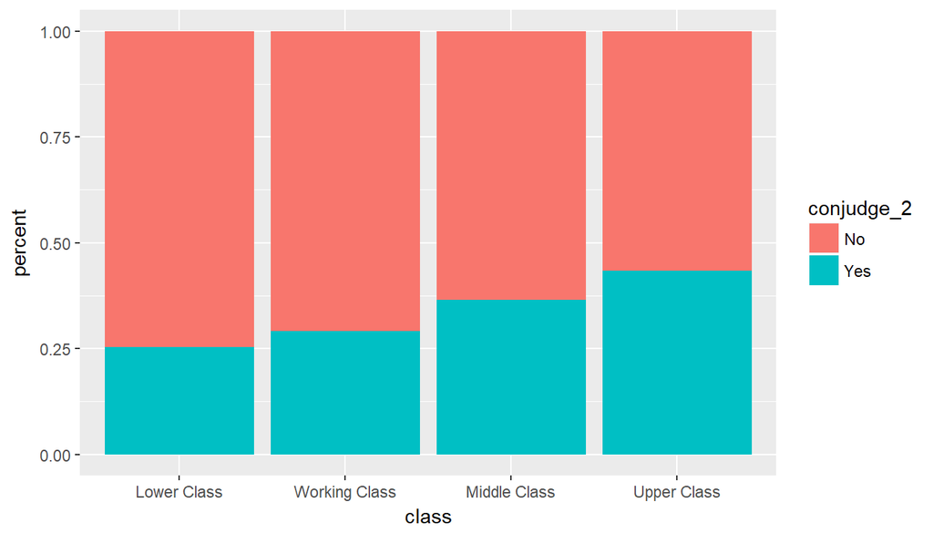

```r
#bar plot for categorical variables conjudge_2 and class after removing NA values. Y axis shows percentage conjudge_2 and x axis shows class

filter(gss2,!is.na(conjudge_2),!is.na(class)) %>% ggplot(aes(x = class, fill = conjudge_2)) + geom_bar(position = "fill") + ylab("percent")
```

##### Narrative

From the graph one can clearly see as the respondent’s class status rises the confidence percentage in the supreme court institution increases.

Addressing the research question there seems to be a positive association between class and the confidence of a person in the institution of supreme court.

#### Summary Statistics

```r
#attaching dataframe to R Search Path

attach(gss2)

#Creating a contingency table of counts

contingency_table <- table(conjudge_2,class)

#This command will give column proportions from the contingency table.

prop.table(contingency_table, 2)
```

```
##           class
## conjudge_2 Lower Class Working Class Middle Class Upper Class
##        No    0.7472745     0.7085897    0.6342896   0.5662960
##        Yes   0.2527255     0.2914103    0.3657104   0.4337040
```

##### Narrative

We can see from the contingency table of column proportions that the percentage of people in each class that responded yes increases as we move to higher socio-economic class category.

Again addressing the research question there seems to be a positive association between class and the confidence of a person in the institution of supreme court.

## Part 4: Inference

#### Hypothesis

$\mathbf{H_0}$ : The confidence a US adult has on the institution of supreme court is independent of the socio-economic class that person belongs to.

$\mathbf{H_A}$ : The confidence a US adult has on the institution of supreme court is not independent of the socio-economic class that person belongs to.

#### Independence Conditions, Appropriate Method and its Description, Test Code and Output

Since the variables are both categorical.

The method of sampling is random.

And the expected counts for each cell is greater than 5 which can be seen from the code output below, hence we use a **Chi Square Test** with $\boldsymbol{\alpha = 0.05}$ whose output is also below.

```r
#Computing Contingency table with expected counts and conducting chi-square test

CrossTable(contingency_table, expected = TRUE, prop.r = FALSE, prop.c = FALSE,
                        prop.t = FALSE, prop.chisq = FALSE)
```

```
##
##
##    Cell Contents
## |-------------------------|
## |                       N |
## |              Expected N |
## |-------------------------|
##
##
## Total Observations in Table:  35438
##
##
##              | class
##   conjudge_2 |   Lower Class | Working Class |  Middle Class |   Upper Class |     Row Total |
## -------------|---------------|---------------|---------------|---------------|---------------|
##           No |          1508 |         11516 |         10148 |           662 |         23834 |
##              |      1357.216 |     10930.362 |     10760.206 |       786.217 |               |
## -------------|---------------|---------------|---------------|---------------|---------------|
##          Yes |           510 |          4736 |          5851 |           507 |         11604 |
##              |       660.784 |      5321.638 |      5238.794 |       382.783 |               |
## -------------|---------------|---------------|---------------|---------------|---------------|
## Column Total |          2018 |         16252 |         15999 |          1169 |         35438 |
## -------------|---------------|---------------|---------------|---------------|---------------|
##
##
## Statistics for All Table Factors
##
##
## Pearson's Chi-squared test
## ------------------------------------------------------------
## Chi^2 =  313.2945     d.f. =  3     p =  1.319019e-67
##
##
##
```

In this method a chi-square statistic $\boldsymbol{\chi^2}$ is computed by adding $\mathbf{\frac{(observed~count - expected~count)^2}{expected~count}}$ for each cell in the contingency table.

The degrees of freedom $\mathbf{df}$ are computed by the formula $\mathbf{(n_{rows} - 1)*(n_{columns} - 1)}$.

The p-value which is computed using $\boldsymbol{\chi^2}$ and the $\mathbf{df}$.

#### Interpretations And Conclusion

The p-value computed is extremely less than our **significance level 0.05** which provides strong evidence against the null hypothesis $\mathbf{H_0}$.

Hence we reject the null hypothesis $\mathbf{H_0}$ and accept the alternative hypothesis $\mathbf{H_A}$ that a US adult’s confidence in supreme court institution is dependent on the socio-economic class that person belongs to.

#### Reasoning why CI is not included

Here we have two categorical variables one of which has more than 2 levels whose independence we are trying to test hence a CI is not included.